# 8 Probability Distributions

## Uniform

A bar chart of the frequency distribution of the 1000 sampled numbers with the possible outcomes (2, 5, 8, 10)

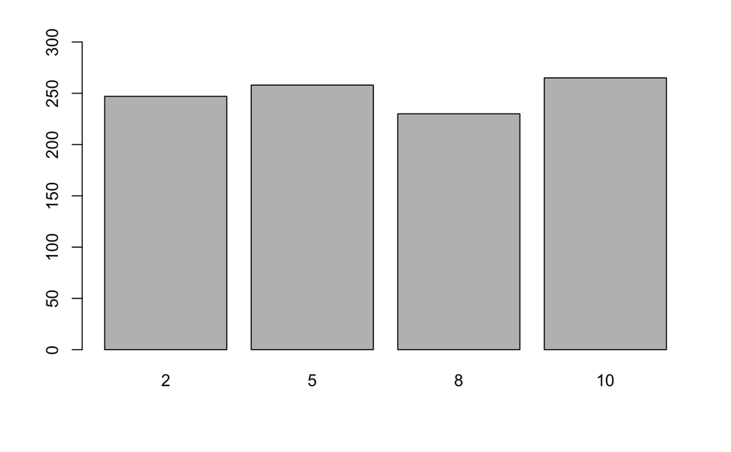

```r
set.seed(123789)
x <- sample(x=c(2,5,8,10), size=1000, replace=T,
prob=c(1/4,1/4,1/4,1/4))
barplot(table(x), ylim=c(0,300))
```

## Binomial

Suppose we roll an unfair die 50 times with the probability of a tail ptail = 0.6. We thus deal with a B(50, 0.6) distribution which can be plotted using the dbinom command. The prefix d stands for “density”.

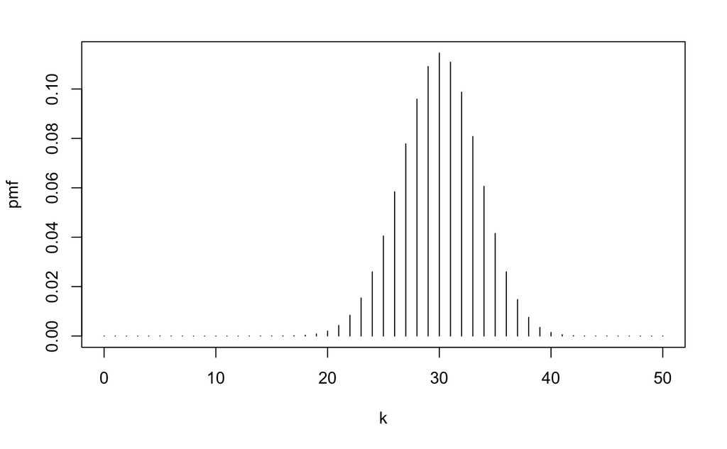

```r
n <- 50
p <- 0.6
k <- 0:n
pmf <- dbinom(k,n,p)
plot(k,pmf, type='h')
```

Note that we can also calculate the CDF with R. We can use the pbinom(x,n,p) command, where the prefix p stands for probability, to calculate the CDF at any point. For example, suppose we are interested in P(X ≥ 30) = 1 − F(29), that is the probability of observing thirty or more tails; then we write

```r
1-pbinom(29,50,0.6)
```

```
[1] 0.5610349
```

Similarly, we can determine quantiles. For instance, the 80 % quantile q which describes that P(X ≤ q) ≥ 0.8 can be obtained by theqbinom(q,n,p)command as follows:

```r
qbinom(0.8,50,0.6)
```

```
[1] 33
```

If we want to generate 100 random realizations from a B(50, 0.6) distribution we can use the rbinom command.

```r
rbinom(100,50,0.6)
```

```
  [1] 32 35 32 29 29 28 26 34 31 31 21 34 27 31 32 23 30 37 29 32 34 31 33 30 29 33 28 32 37 30 29 34
 [33] 31 31 30 32 30 36 28 34 25 35 28 30 26 26 28 35 29 26 24 32 37 28 28 30 26 25 31 27 31 30 34 27
 [65] 35 30 31 31 29 28 33 22 32 36 35 30 26 30 35 33 31 31 29 38 27 29 26 30 30 34 32 32 34 34 29 32
 [97] 25 33 20 28
```

## Poisson

Example 8.1.6 Suppose a country experiences X = 4 tropical storms on average per year. Then the probability of suffering from only two tropical storms is obtained by using the Poisson distribution as

$$P(X=2) = \frac{\lambda^x}{x!}e^{\lambda} = \frac{4^2}{2!}e^{-4} = 0.146525$$

If we are interested in the probability that not more than 2 storms are experienced, then

```r
dpois(2,4) + dpois(1,4) + dpois(0,4)
```

```
[1] 0.2381033
```

## Estimating the mean with confidence intervals

```r
x <- iris$Sepal.Length
t.test(x, conf.level=0.95)
```

```
    One Sample t-test

data:  x
t = 86.425, df = 149, p-value < 2.2e-16
alternative hypothesis: true mean is not equal to 0
95 percent confidence interval:
 5.709732 5.976934
sample estimates:
mean of x
 5.843333
```

## Ploting a ML Estimator function

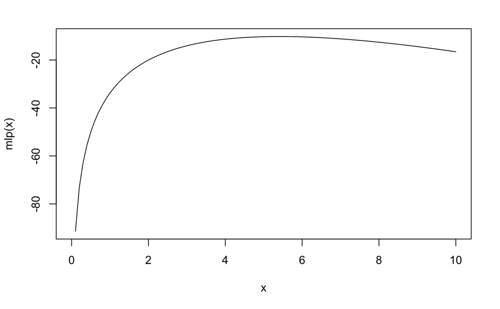

```r
mlp <- function(lambda) {
    27 * log(lambda) - log(factorial(4) * factorial(3) * factorial(8) * factorial(6) * factorial(6)) - 5 * lambda
}
curve(mlp, from=0, to=10)
```